# STA553 HW2

Michael Tarrant

2/13/22

```r
x<-read.csv("https://raw.githubusercontent.com/minefieldmike/DataViz/main/data/w02-penguins.csv")
table(x$species)
```

```
##
##    Adelie Chinstrap    Gentoo
##       152        68       124
```

```r
table(x$island)
```

```
##
##    Biscoe     Dream Torgersen
##       168       124        52
```

```r
summary(x$body_mass_g)
```

```
##    Min. 1st Qu.  Median    Mean 3rd Qu.    Max.    NA's
##    2700    3550    4050    4202    4750    6300       2
```

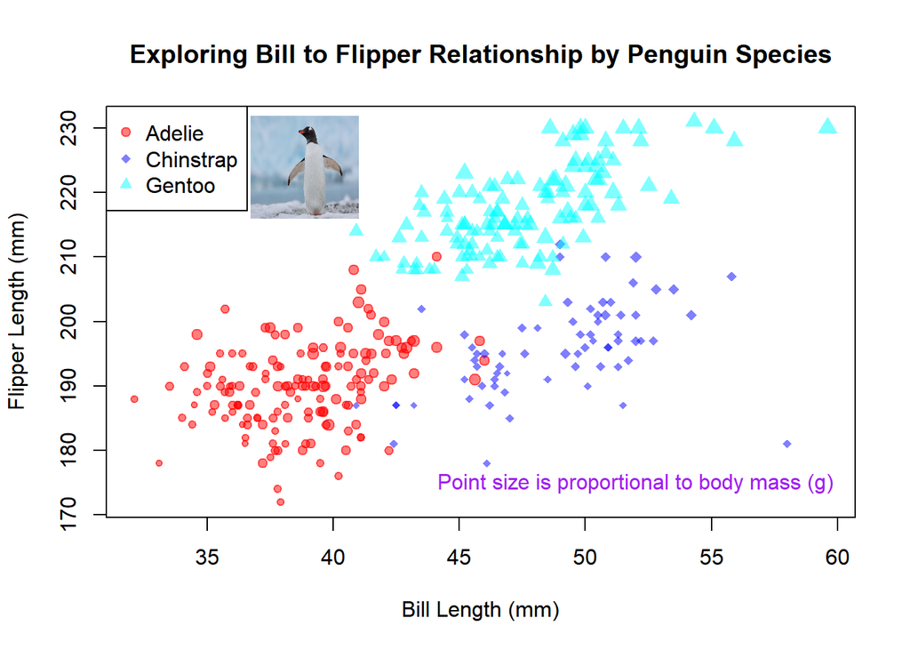

```r
bill.length = x$bill_length_mm
flipper.length = x$flipper_length_mm
size.body = x$body_mass_g/4000
species = x$species
adelie.id = which(species=="Adelie")  # value are case sensitive!
chinstrap.id = which(species=="Chinstrap")
gentoo.id = which(species=="Gentoo")
## color code
col.code = c(alpha("red",0.5),alpha("blue",0.5),alpha("cyan",0.5))
## making an empty plot: type = "n" ==> no point
plot(bill.length, flipper.length, main = "Exploring Bill to Flipper Relationship by Penguin Species", type = "n", xlab="Bill Length (mm)", ylab="Flipper Length (mm)")
## change the point size based on their weight
points(bill.length[adelie.id], flipper.length[adelie.id],
       pch = 19, col = col.code[1], cex = size.body[adelie.id])
points(bill.length[chinstrap.id], flipper.length[chinstrap.id],
       pch = 18, col = col.code[2], cex = size.body[chinstrap.id])
points(bill.length[gentoo.id], flipper.length[gentoo.id],
       pch = 17, col = col.code[3], cex = size.body[gentoo.id])
legend("topleft", c("Adelie", "Chinstrap", "Gentoo"),
                  col=col.code,
                  pch=c(19, 18, 17))
text(52, 175, "Point size is proportional to body mass (g)", col = "purple", cex = 1)
myurl<-"https://raw.githubusercontent.com/minefieldmike/DataViz/main/images/studying-penguin-poo-t.jpg"
z<-tempfile()
download.file(myurl,z,mode="wb")
pic<-readJPEG(z)
raster.penguin<-as.raster(pic)
rasterImage(raster.penguin,36.7,216,41,232)
```

```r
subset<- x %>%
  na.omit %>%
  filter(species=="Adelie" | species=="Gentoo",island=="Biscoe" | island=="Torgersen",body_mass_g<5000 & body_mass_g>3500) %>%
  mutate(BMI=body_mass_g/4000) %>%
  select(-X,-sex,-year,-body_mass_g)
```

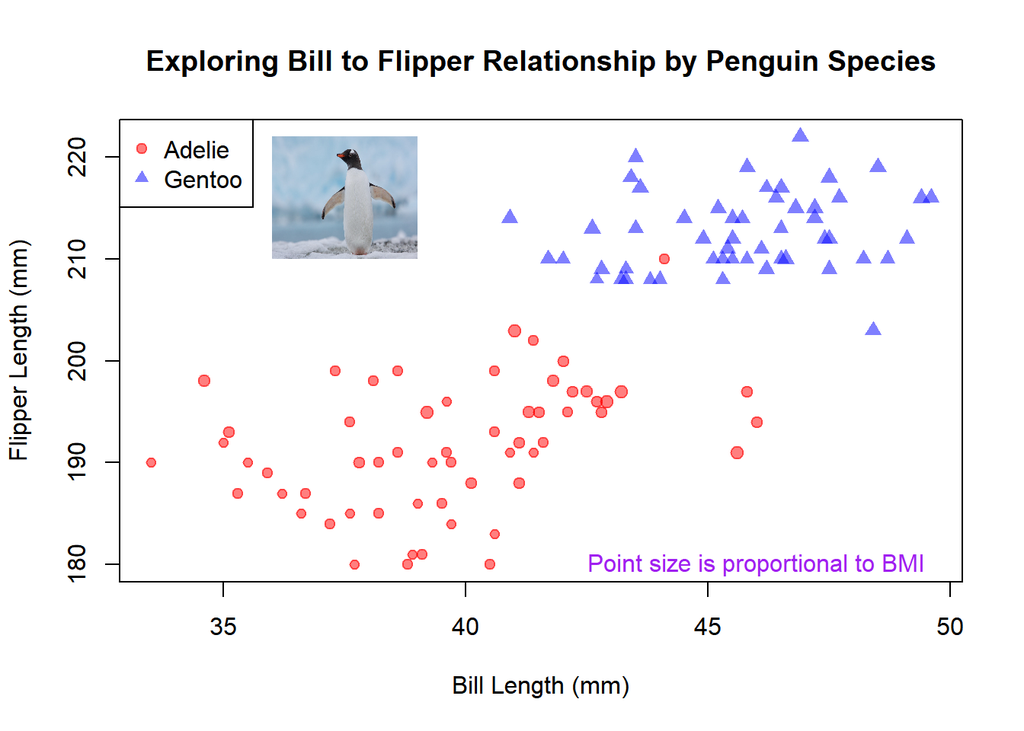

```r
bill.length = subset$bill_length_mm
flipper.length = subset$flipper_length_mm
species = subset$species
adelie.id = which(species=="Adelie")  # value are case sensitive!
gentoo.id = which(species=="Gentoo")
## color code
col.code = c(alpha("red",0.5),alpha("blue",0.5),alpha("cyan",0.5))
## making an empty plot: type = "n" ==> no point
plot(bill.length, flipper.length, main = "Exploring Bill to Flipper Relationship by Penguin Species", type = "n", xlab="Bill Length (mm)", ylab="Flipper Length (mm)")
## change the point size based on their weight
points(bill.length[adelie.id], flipper.length[adelie.id],
       pch = 19, col = col.code[1], cex = subset$BMI[adelie.id])
points(bill.length[gentoo.id], flipper.length[gentoo.id],
       pch = 17, col = col.code[2], cex = subset$BMI[gentoo.id])
legend("topleft", c("Adelie", "Gentoo"),
                  col=col.code,
                  pch=c(19, 17))
text(46, 180, "Point size is proportional to BMI", col = "purple", cex = 1)
myurl<-"https://raw.githubusercontent.com/minefieldmike/DataViz/main/images/studying-penguin-poo-t.jpg"
z<-tempfile()
download.file(myurl,z,mode="wb")
pic<-readJPEG(z)
raster.penguin<-as.raster(pic)
rasterImage(raster.penguin,36,210,39,222)
```

The relationship between Bill Length and Flipper Length appears to be similar between Adelie and Gentoo penguins in the Biscoe and Torgersen islands for penguins between 3500 and 5000 grams. The Adelie penguins meeting this criteria may have a slightly higher slope, meaning as Bill Length increases we expect Flipper Length to increase faster than it does in their Gentoo counterparts, but it is hard to tell due to the wider variance in both Bill Length and Flipper Length. This also means the Least Squares Regression Line could not be significant, due to the correlation being too weak. The Gentoo penguins are more homogeneous, with few outliers straying too far from the group. Visually, it could be argued there is a slight positive relationship between the aforementioned features, or none at all. Due to the proximity is certain Gentoo penguins, Least Squares Estimation may all but flatten the line relating Bill Length and Flipper Length. Also, an interesting note about classification, there appears to be one Adelie penguin whose features might lead researchers to believe it is a Gentoo, while the Gentoo are largely grouped together, save for one with abnormally short flippers for its bill length, though no Adelie penguins have similar bills (to this particular Gentoo).